# Untitled4-Copy1

```python
import torch
from torch.autograd import Variable
import numpy as np
import torch.nn.functional as F
import torchvision
from torchvision import transforms
import torch.optim as optim
from torch import nn
import matplotlib.pyplot as plt
from torch import distributions
import numpy as np
import math
import os
import itertools
from torch.utils.tensorboard import SummaryWriter
import torchvision.transforms as transforms
from torch.utils.data import DataLoader
from torchvision import datasets
from torch.autograd import Variable
from torch.utils.tensorboard import SummaryWriter
import torch.nn as nn
import torch.nn.functional as F
import torch



cuda = True if torch.cuda.is_available() else False
Tensor = torch.cuda.FloatTensor if cuda else torch.FloatTensor
```

```python
class Flatten(nn.Module):
    def forward(self, input):
        return input.view(input.size(0), -1)


class UnFlatten(nn.Module):
    def forward(self, input, size=256):
        return input.view(input.size(0), 256, 1, 1)

def reparam(mu,logvar):
    std = torch.exp(logvar/2)
    #print(mu.size(0),64)
    z =  Variable(torch.Tensor(np.random.normal(0, 1, (mu.size(0), 64))))
    #print(z.shape,mu.shape,std.shape)
    return mu + z*std

class Encoder(nn.Module):
    def __init__(self,image_channels=3,fc_dim=256,latent_size=128):
        super(Encoder,self).__init__()
        self.encoder = nn.Sequential(
                nn.Conv2d(image_channels, 32, 4, 2),
                nn.ReLU(0.2),
                nn.Conv2d(32, 64, 2, 2),
                nn.ReLU(0.2),
                nn.Conv2d(64, 128, 2, 2),
                nn.ReLU(0.2),
                nn.Conv2d(128, 256, 2, 2),
                nn.ReLU(0.2),
                Flatten(),
            )
        self.encoder_mean = nn.Linear(fc_dim, latent_size)
        self.encoder_logvar = nn.Linear(fc_dim, latent_size)
    def forward(self,x):
        x = self.encoder(x)
        #print(x.shape)
        mu = self.encoder_mean(x)
        log_var = self.encoder_logvar(x)
        return x,mu,log_var
```

```python
batch_size = 32
latent_dim = 64
class Discriminator(nn.Module):
    def __init__(self,in_channels=3,out_channels=1,base_channels=32,dropout=0.3):
        super(Discriminator,self).__init__()
        self.model1 = nn.Sequential(
                  nn.Conv2d(3, 64, kernel_size=(4, 4),stride=(2, 2),padding=(2, 2)),
                  nn.BatchNorm2d(64, eps=1e-05, momentum=0.1, affine=True, track_running_stats=True),
                  nn.LeakyReLU(negative_slope=0.2),
                  nn.Conv2d(64, 128, kernel_size=(4, 4), stride=(2, 2), padding=(2, 2)),
                  nn.BatchNorm2d(128, eps=1e-05, momentum=0.1, affine=True, track_running_stats=True),
                  nn.LeakyReLU(negative_slope=0.2),
                  nn.Dropout(p=0.3, inplace=False),
                  nn.Conv2d(128,256, kernel_size=(4, 4), stride=(2, 2), padding=(2, 2)),
                  nn.BatchNorm2d(256, eps=1e-05, momentum=0.1, affine=True, track_running_stats=True),
                  nn.LeakyReLU(negative_slope=0.2),
                  nn.Dropout(p=0.3, inplace=False),
                  nn.Conv2d(256, 512, kernel_size=(4, 4), stride=(2, 2), padding=(2, 2)),
                  nn.BatchNorm2d(512, eps=1e-05, momentum=0.1, affine=True, track_running_stats=True),
                  nn.LeakyReLU(negative_slope=0.2),
                  nn.Dropout(p=0.3, inplace=False),
                  nn.Conv2d(512, 1, kernel_size=(4, 4), stride=(4, 4), padding=(2, 2)),
                  nn.Sigmoid())

    def forward(self,x):
        return self.model1(x)
input = torch.rand(32, 3,32,32)
```

```python
def vae_loss_function(recons, target, mu, log_var, lambda_kld=1e-3):
    """
    Combined loss function for joint optimization of
    reconstruction and ELBO
    """
    recons_loss = F.mse_loss(recons, target)
    kld = (-0.5 * (1 + log_var - mu**2 - log_var.exp()).sum(dim=1)).mean(dim=0)
    loss = recons_loss + lambda_kld * kld

    return loss, (recons_loss, kld)
```

```python
class Decoder(nn.Module):
    def __init__(self,image_channels=3,hidden_size=256,latent_size=64):
        super(Decoder,self).__init__()
        self.decoder = nn.Sequential(
                UnFlatten(),
                nn.ConvTranspose2d(hidden_size, 128, 2, 2),
                nn.ReLU(),
                nn.ConvTranspose2d(128, 64, 2, 2),
                nn.ReLU(),
                nn.ConvTranspose2d(64, 32, 2, 2),
                nn.ReLU(),
                nn.ConvTranspose2d(32, 32, 2, 2),
                nn.ReLU(),
                nn.ConvTranspose2d(32, image_channels, 2, 2),
                nn.Sigmoid(),
            )
    def forward(self,x):
        x = self.decoder(x)
        return x
```

```python
class Discriminator(nn.Module):
    def __init__(self,hidden_size=256):
        super(Discriminator, self).__init__()
        #print("Latent",latent_dim)
        self.model = nn.Sequential(
            nn.Linear(hidden_size, 512),
            nn.LeakyReLU(0.2, inplace=True),
            nn.Linear(512, 256),
            nn.LeakyReLU(0.2, inplace=True),
            nn.Linear(256, 1),
            nn.Sigmoid(),
        )

    def forward(self, z):
        #print("Shape Z:",z.shape)
        validity = self.model(z)
        #print("Val:",validity.shape)
        return validity
```

```python
lr = 0.0002
b1 = 0.5
b2 = 0.999
latent_dim = 64
img_size = 32
channels = 3
sample_interval = 400


#encoder = Encoder()
#encoded_image,mu,log_var = enc(torch.rand(32,3,32,32))
#print(encoded_image.shape)
#print(mu.shape)
#decoder = Decoder()
#p = dec(encoded_image)
#print(p.shape)

z = Variable(torch.Tensor(np.random.normal(0, 1, (32, 64))))

encoder = Encoder()
decoder = Decoder()
discriminator = Discriminator()
adversarial_loss = torch.nn.BCELoss()
pixelwise_loss = torch.nn.L1Loss()

if cuda:
    encoder.cuda()
    decoder.cuda()
    discriminator.cuda()
    adversarial_loss.cuda()
    pixelwise_loss.cuda()

opt_G = torch.optim.Adam(itertools.chain(encoder.parameters(), decoder.parameters()), lr=lr, betas=(b1, b2))

opt_D = torch.optim.Adam(discriminator.parameters(), lr=lr, betas=(b1, b2))
```

```python
@torch.no_grad()
def img_regeneration(model):
    test_z = torch.normal(0, 1, size=(32, 256)).cuda()
    out = model(test_z)
    out = [i.cpu() for i in out[0:8]]
    out = [i.permute(1,2,0) for i in out[0:8]]
    return out
```

```python
transform = transforms.Compose([transforms.Resize(32),
                                transforms.CenterCrop(32),
                                transforms.ToTensor(),
                                ])


dataset = datasets.CelebA('./', split="train", download=True, transform=transform)
dataloader = torch.utils.data.DataLoader(dataset, batch_size=batch_size,
                                         shuffle=True, num_workers=8, drop_last=True)  # Batch size of 128 used
```

```
Files already downloaded and verified
```

```python
GAN_LOGS = os.path.join(os.getcwd(), "tboard_logs", "AA_VAE")
if not os.path.exists(GAN_LOGS):
    os.makedirs(GAN_LOGS)

shutil.rmtree(GAN_LOGS)
writer = SummaryWriter(GAN_LOGS)
```

```python
g_loss_li = []
d_loss_li = []
```

```
[Epoch 1] [Batch 2289/5086] [D loss: 0.000273] [G loss: 0.145245]
```

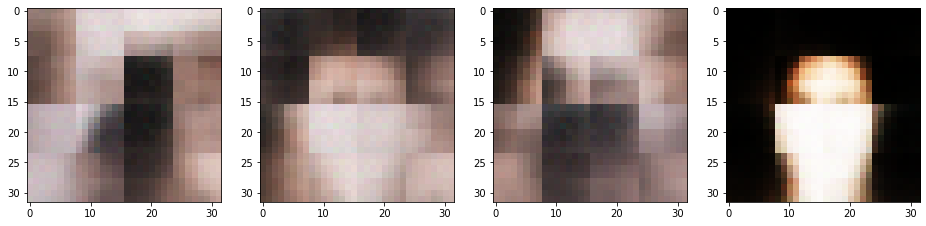

```
[Epoch 2] [Batch 2289/5086] [D loss: 0.000085] [G loss: 0.135247]
```

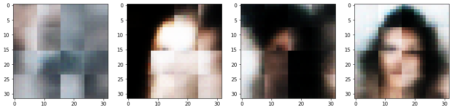

```
[Epoch 3] [Batch 2289/5086] [D loss: 0.000078] [G loss: 0.122857]
```

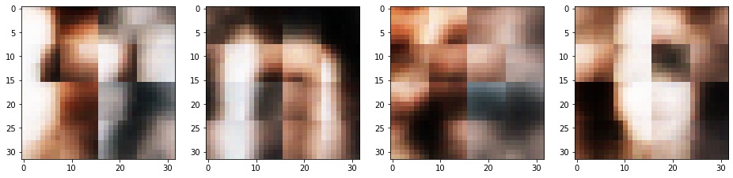

```
[Epoch 4] [Batch 2289/5086] [D loss: 0.000060] [G loss: 0.132671]
```

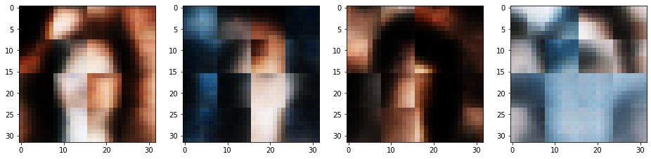

```
[Epoch 5] [Batch 2289/5086] [D loss: 0.000043] [G loss: 0.127379]
```

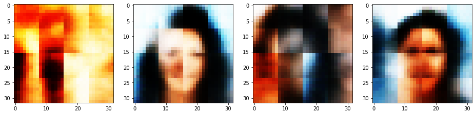

```
[Epoch 6] [Batch 2289/5086] [D loss: 0.000009] [G loss: 0.118853]
```

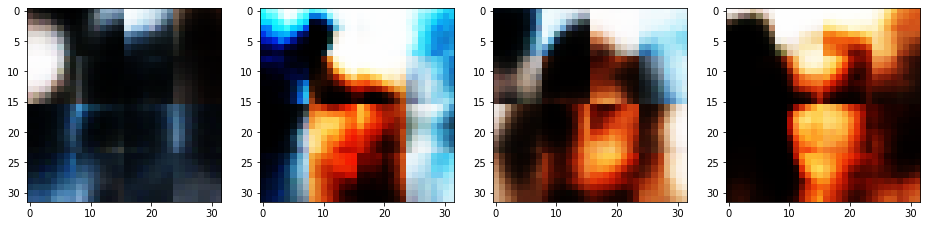

```
[Epoch 7] [Batch 2289/5086] [D loss: 0.000000] [G loss: 0.121547]
```

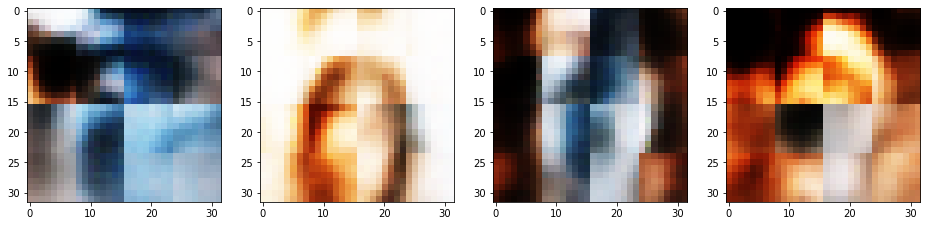

```
[Epoch 8] [Batch 2289/5086] [D loss: 0.000000] [G loss: 0.135689]
```

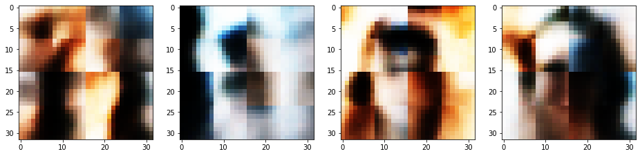

```
[Epoch 9] [Batch 2289/5086] [D loss: 0.000032] [G loss: 0.127805]
```

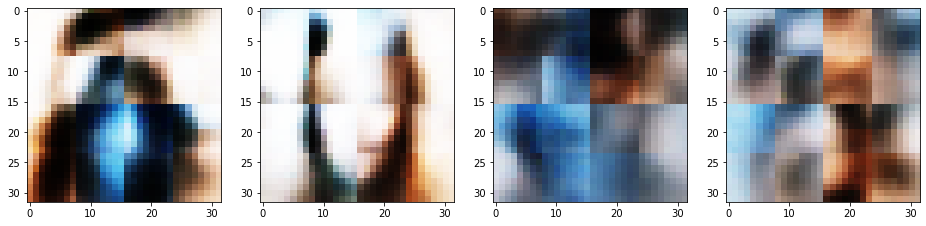

```
[Epoch 10] [Batch 2289/5086] [D loss: 0.000047] [G loss: 0.119621]
```

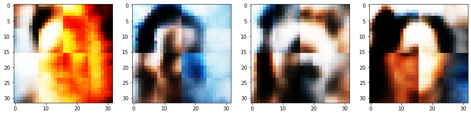

```
[Epoch 11] [Batch 2289/5086] [D loss: 0.000063] [G loss: 0.112730]
```

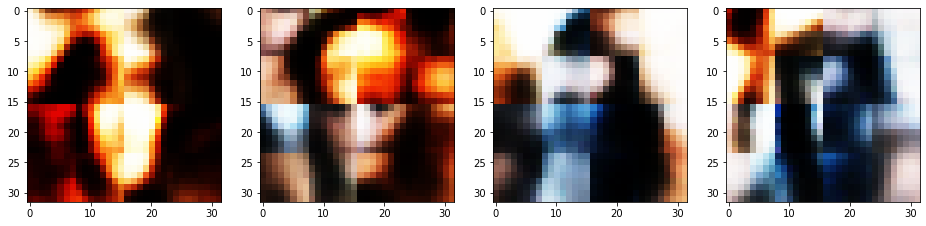

```
[Epoch 12] [Batch 2289/5086] [D loss: 0.000002] [G loss: 0.113285]
```

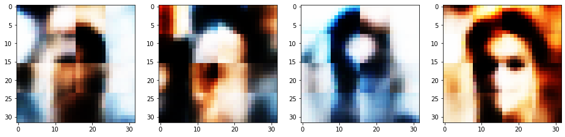

```
[Epoch 13] [Batch 2289/5086] [D loss: 0.000034] [G loss: 0.111900]
```

[42 more figures not shown]

[output not shown]

```python
for epoch in range(1,100+1):
    for i, (imgs, _) in enumerate(dataloader):
        ONES = Variable(torch.Tensor(imgs.shape[0], 1).fill_(1.0), requires_grad=False).cuda()
        #print(ONES.shape)
        ZEROS = Variable(torch.Tensor(imgs.shape[0], 1).fill_(0.0), requires_grad=False).cuda()

        # Configure input
        real_imgs = Variable(imgs.type(torch.Tensor)).cuda()

        # -----------------
        #  Train Generator
        # -----------------
        opt_G.zero_grad()
        opt_D.zero_grad()
        #print(real_imgs.shape)
        encoded_imgs,mu,log_var = encoder(imgs.cuda())
        encoded_imgs = encoded_imgs.cuda()
        decoded_imgs = decoder(encoded_imgs).cuda()

        # Generator Loss
        #print("Encoded shape Gen LOss:",encoded_imgs.shape)
        disc = discriminator(encoded_imgs).cuda()
        ad_loss_val = adversarial_loss(disc, ONES).cuda()
        pixel_loss_val = pixelwise_loss(decoded_imgs, real_imgs).cuda()
        g_loss = 0.001 * ad_loss_val + 0.999 * pixel_loss_val
        g_loss = g_loss.cuda()
        g_loss.backward()
        opt_G.step()

        # ---------------------
        #  Train Discriminator
        # ---------------------
        opt_D.zero_grad()
        z = Variable(torch.Tensor(np.random.normal(0, 1, (imgs.shape[0], 256)))).cuda()

        # Discriminator Loss
        #print("Encoded shape Gen LOss:",discriminator(z).shape)
        real_loss = adversarial_loss(discriminator(z).cuda(), ONES.cuda())
        fake_loss = adversarial_loss(discriminator(encoded_imgs.detach()), ZEROS)
        d_loss = 0.5 * (real_loss + fake_loss)
        writer.add_scalar(f'Loss/Generator Loss', g_loss.item(), global_step=iter_)
        writer.add_scalar(f'Loss/Discriminator Loss', d_loss.item(), global_step=iter_)
        writer.add_scalars(f'Loss/Discriminator Losses', {
                "Real Images Loss": real_loss.item(),
                "Fake Images Loss": fake_loss.item(),
            }, global_step=iter_)
        d_loss.backward()
        opt_D.step()
        if(i==2289):
            print(
              "[Epoch %d] [Batch %d/%d] [D loss: %f] [G loss: %f]"
              % (epoch, i, len(dataloader), d_loss.item(), g_loss.item())
              )
            out = img_regeneration(decoder)
            fig, ax = plt.subplots(1, 4)
            fig.set_size_inches(16, 4)
            for i in range(4):
                ax[i].imshow(out[i])
            plt.show()
    d_loss_li.append(d_loss.item())
    g_loss_li.append(g_loss.item())
    writer.add_scalars(f'Comb_Loss/Losses', {
                    'Discriminator': d_loss.item(),
                    'Generator':  g_loss.item()
                }, iter_)
```

```python
@torch.no_grad()
def img_regeneration(model):
    test_z = torch.normal(0, 1, size=(32, 256)).cuda()
    print(test_z.shape)
    out = model(test_z)
    out = [i.cpu() for i in out[0:8]]
    out = [i.permute(1,2,0) for i in out[0:8]]
    return out
```

```
torch.Size([32, 256])
```

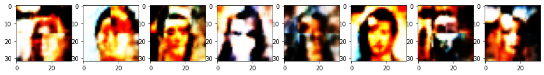

```python
out = img_regeneration(decoder)
fig, ax = plt.subplots(1, 8)
fig.set_size_inches(16, 4)
out = [out[i].numpy() for i in range(8)]

for i in range(8):
    ax[i].imshow(out[i])
plt.show()
```

These are some of the generated images from the the generator and it looks like the model is learning to produce some of the reconstructions as 6th images can be woman as well as man

```python
def smooth(f, K=5):
    """ Smoothing a function using a low-pass filter (mean) of size K """
    kernel = np.ones(K) / K
    f = np.concatenate([f[:int(K//2)], f, f[int(-K//2):]])  # to account for boundaries
    smooth_f = np.convolve(f, kernel, mode="same")
    smooth_f = smooth_f[K//2: -K//2]  # removing boundary-fixes
    return smooth_f
```

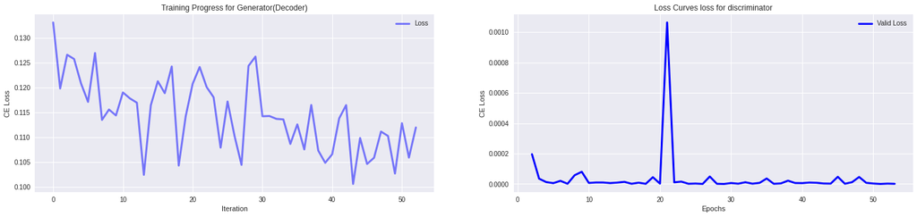

```python
plt.style.use('seaborn')
fig, ax = plt.subplots(1,2)
fig.set_size_inches(24,5)

smooth_loss = smooth(d_loss_li, 31)
ax[0].plot(g_loss_li, c="blue", label="Loss", linewidth=3, alpha=0.5)
ax[0].legend(loc="best")
ax[0].set_xlabel("Iteration")
ax[0].set_ylabel("CE Loss")
ax[0].set_title("Training Progress for Generator(Decoder)")

epochs = np.arange(len(d_loss_li)) + 1
ax[1].plot(epochs[1:], d_loss_li[1:], c="blue", label="Valid Loss", linewidth=3)
ax[1].legend(loc="best")
ax[1].set_xlabel("Epochs")
ax[1].set_ylabel("CE Loss")
ax[1].set_title("Loss Curves loss for discriminator")

plt.show()
```

The Generator loss starts high and then on and off, it tries to be less and less (meaning the generator is trying to improve) At the same time, the discriminator is quite low on the loss as it has a very easy task at hand. Also, for the sake complexity of the assignment, we tried a very simple discriminator (That uses Linear layer to reduce dimensionality). So, that one of the main reasons in this case that the generator is not beating the discriminator.